# Explore VQSR VCF

Alexey Larionov

15/03/2019

started: AL13Aug2018  
last updated: AL15Mar2019

# Summary

Read vcf to R (12,902 variants x 739 cases) and explore selected QC metrics

Exploration shows that:

Before filtering, Ampliseq raw vcf has much more variants than raw WES vcf: ~13k vs ~4.5 k

applying filters used in WES (DP>10 x samples & PASS) + remove over-covered variants (avg DP > 100,000)  
preserves ~50% of variants (~7k), which is still much more than the num of vars in the filtered WES data (~3.5k)

Filtering by QUAL is compromised by inverse relation of QUAL and Ts/Tv (in bcftools stats results).  
However, it may be explored later if necessary: it might remove another ~50% of variants  
(disproportionaly higher than ~10% in WES).

VQSRLOD threshold for PASS looks reasonable.

As in WES data, missingness of genotypes is higher in NFE than in WECARE.  
This will be dealt with later.

Suggested hard filters at this stage:

- Average DP > 10x num samples
- Average DP < 100,000
- VQSR PASS

# Start section

```r
Sys.time()
```

```
## [1] "2019-03-15 22:03:09 GMT"
```

```r
rm(list=ls())
graphics.off()

library(knitr)
library(dplyr)
library(vcfR) # for reading VCF
base_folder="/Users/alexey/Documents/wecare/ampliseq/analysis4/s03_explore_vqsr_vcf"
setwd(base_folder)

opts_knit$set(root.dir = base_folder)
options(stringsAsFactors = F,
        warnPartialMatchArgs = T,
        warnPartialMatchAttr = T,
        warnPartialMatchDollar = T)

#options(error = browser()) # Type Q or c to exit, drop browser level
# https://support.rstudio.com/hc/en-us/articles/200713843?version=1.1.456&mode=desktop
# https://stackoverflow.com/questions/13052522/how-to-leave-the-r-browser-mode-in-the-console-window/13052588
```

# Read vcfr

```r
# Source VCF
vcf_file=paste(base_folder, "ampliseq_nfe_vqsr.vcf", sep="/")

# Read vcf to vcfR object
vcfr <- read.vcfR(vcf_file)
```

[output not shown]

```r
# Clean-up
rm(vcf_file)
```

# Extract meta and fixed

```r
# Get data from header and fixed columns
meta_fix <- vcfR2tidy(vcfr, info_only=T)

# Get data frame with meta-information from vcf header
meta.df <- meta_fix$meta
dim(meta.df)
```

```
## [1] 27  5
```

```r
meta.df
```

```
## # A tibble: 27 x 5
##    Tag   ID              Number Type    Description
##    <chr> <chr>           <chr>  <chr>   <chr>
##  1 INFO  AC              A      Integer Allele count in genotypes, for each ALT allele, in the same order as listed
##  2 INFO  AF              A      Float   Allele Frequency, for each ALT allele, in the same order as listed
##  3 INFO  AN              1      Integer Total number of alleles in called genotypes
##  4 INFO  AS_FilterStatus A      String  Filter status for each allele, as assessed by ApplyRecalibration. Note that the VCF filter field will reflect the most lenient/sensitive status across all alleles.
##  5 INFO  AS_VQSLOD       A      String  For each alt allele, the log odds of being a true variant versus being false under the trained gaussian mixture model
##  6 INFO  AS_culprit      A      String  For each alt allele, the annotation which was the worst performing in the Gaussian mixture model, likely the reason why the variant was filtered out
##  7 INFO  BaseQRankSum    1      Float   Z-score from Wilcoxon rank sum test of Alt Vs. Ref base qualities
##  8 INFO  ClippingRankSum 1      Float   Z-score From Wilcoxon rank sum test of Alt vs. Ref number of hard clipped bases
##  9 INFO  DP              1      Integer Approximate read depth; some reads may have been filtered
## 10 INFO  DS              0      Flag    Were any of the samples downsampled?
## # … with 17 more rows
```

```r
# Get data frame with fixed columns (including parsed INFO, convert tibble to data-frame)
fixed.df <- as.data.frame(meta_fix$fix)
dim(fixed.df)
```

```
## [1] 12902    34
```

```r
colnames(fixed.df)
```

```
##  [1] "CHROM"               "POS"                 "ID"                  "REF"                 "ALT"                 "QUAL"                "FILTER"              "AC"                  "AF"                  "AN"                  "AS_FilterStatus"     "AS_VQSLOD"           "AS_culprit"          "BaseQ…
```

```r
fixed.df[1:5,1:7]
```

```
##   CHROM     POS   ID REF ALT       QUAL FILTER
## 1     1 3668950 <NA>   A   G   23805.04   PASS
## 2     1 3669102 <NA>   G   A    1057.45   PASS
## 3     1 3669172 <NA>   C   T 1167626.35   PASS
## 4     1 3669201 <NA>   A   G 8134730.17   PASS
## 5     1 3669205 <NA>   C   G 9502881.12   PASS
```

```r
# Clean-up
rm(meta_fix)
```

# Extract gt matrix

```r
# Genotypes matrix with numeric representation of alleles
gt_num.mx <- extract.gt(vcfr) # original numeric codes: 0/1, 1/1 etc
dim(gt_num.mx)
```

```
## [1] 12902   739
```

```r
gt_num.mx[1:5,6:10]
```

```
##           105_S337_L008 106_S303_L008 107_S467_L008 108_S482_L008 109_S484_L008
## 1_3668950 "0/0"         "0/0"         "0/0"         NA            "0/0"
## 1_3669102 "0/0"         "0/0"         "0/0"         NA            "0/0"
## 1_3669172 "0/0"         "0/0"         "0/0"         NA            "0/0"
## 1_3669201 "1/1"         "0/1"         "0/1"         NA            "0/1"
## 1_3669205 "1/1"         "0/1"         "0/1"         NA            "0/1"
```

```r
sum(is.na(gt_num.mx))
```

```
## [1] 785051
```

```r
sum(!is.na(gt_num.mx))
```

```
## [1] 8749527
```

```r
sum(is.na(gt_num.mx))/sum(!is.na(gt_num.mx))
```

```
## [1] 0.08972496
```

```r
# Clean-up
rm(vcfr)
```

# Explore missed values in standard VEP fileds

```r
# Count missed values
sum(is.na(fixed.df))
```

```
## [1] 65807
```

```r
sum(fixed.df == "", na.rm=T)
```

```
## [1] 0
```

```r
sum(fixed.df == ".", na.rm=T)
```

```
## [1] 0
```

```r
# Function to check for blanks in a vector
sum_na.udf <- function(x){sum(is.na(x))}

# Look up columns that contain blanks
x <- apply(fixed.df,2,sum_na.udf)
names(x) <- colnames(fixed.df)
x[x>0]
```

```
##              ID    BaseQRankSum ClippingRankSum             END  HaplotypeScore InbreedingCoeff       MQRankSum  ReadPosRankSum          VQSLOD         culprit
##           12902             321             321           12902           12902              12             321             322           12902           12902
```

```r
# A uniform field (Were any of the samples downsampled?)
table(fixed.df$DS)
```

```
##
## FALSE
## 12902
```

```r
# Remove empty and uniform fields
fixed.df <- fixed.df %>%
  select(-ID, -END, -HaplotypeScore, -VQSLOD, -culprit, -DS)

# Clean-up
rm(x, sum_na.udf)
```

Compare missed genotypes in Ampliseq and NFE

```r
head(colnames(gt_num.mx))
```

```
## [1] "100_S8_L007"   "101_S528_L008" "102_S466_L008" "103_S147_L007" "104_S325_L008" "105_S337_L008"
```

```r
tail(colnames(gt_num.mx))
```

```
## [1] "NA20819" "NA20821" "NA20822" "NA20826" "NA20828" "NA20832"
```

```r
colnames(gt_num.mx)[541:542]
```

```
## [1] "9_S346_L008" "HG00097"
```

```r
dim(gt_num.mx)
```

```
## [1] 12902   739
```

```r
gt_ampliseq.df <- gt_num.mx[,1:541]
gt_nfe.df <- gt_num.mx[,542:739]

sum(is.na(gt_ampliseq.df)/(nrow(gt_ampliseq.df)*ncol(gt_ampliseq.df))) # length(gt_ampliseq.df) could be used
```

```
## [1] 0.06124844
```

```r
sum(is.na(gt_nfe.df)/length(gt_nfe.df))
```

```
## [1] 0.1399587
```

```r
rm(gt_ampliseq.df, gt_nfe.df)
```

# FILTER

```r
table(fixed.df$FILTER)
```

```
##
##                          PASS  VQSRTrancheINDEL95.00to97.00  VQSRTrancheINDEL97.00to99.00 VQSRTrancheINDEL99.00to100.00    VQSRTrancheSNP97.00to99.00   VQSRTrancheSNP99.00to100.00
##                          8962                           276                           447                           373                          1563                          1281
```

```r
sum((fixed.df$FILTER=="PASS"))/length(fixed.df$FILTER)
```

```
## [1] 0.694621
```

# QUAL

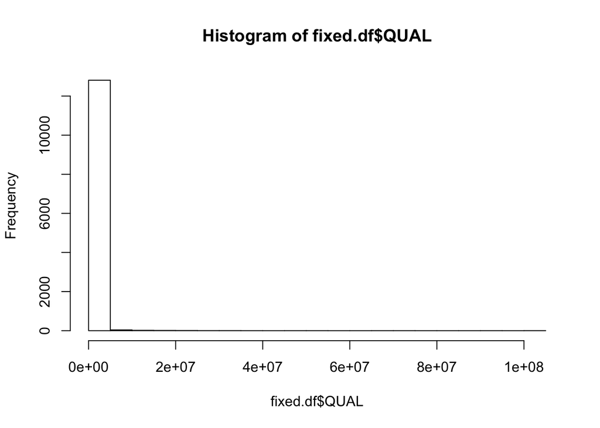

```r
hist(fixed.df$QUAL)
```

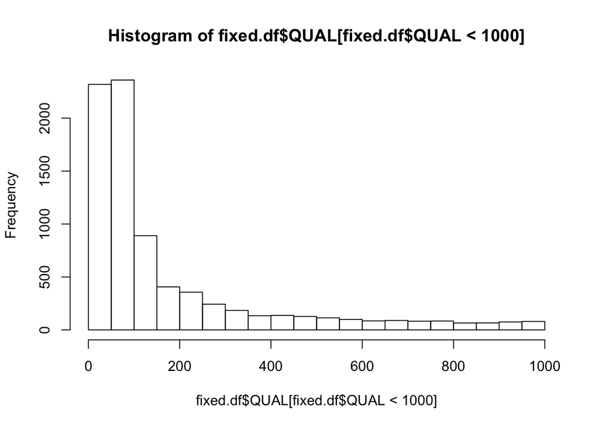

```r
hist(fixed.df$QUAL[fixed.df$QUAL<1000])
```

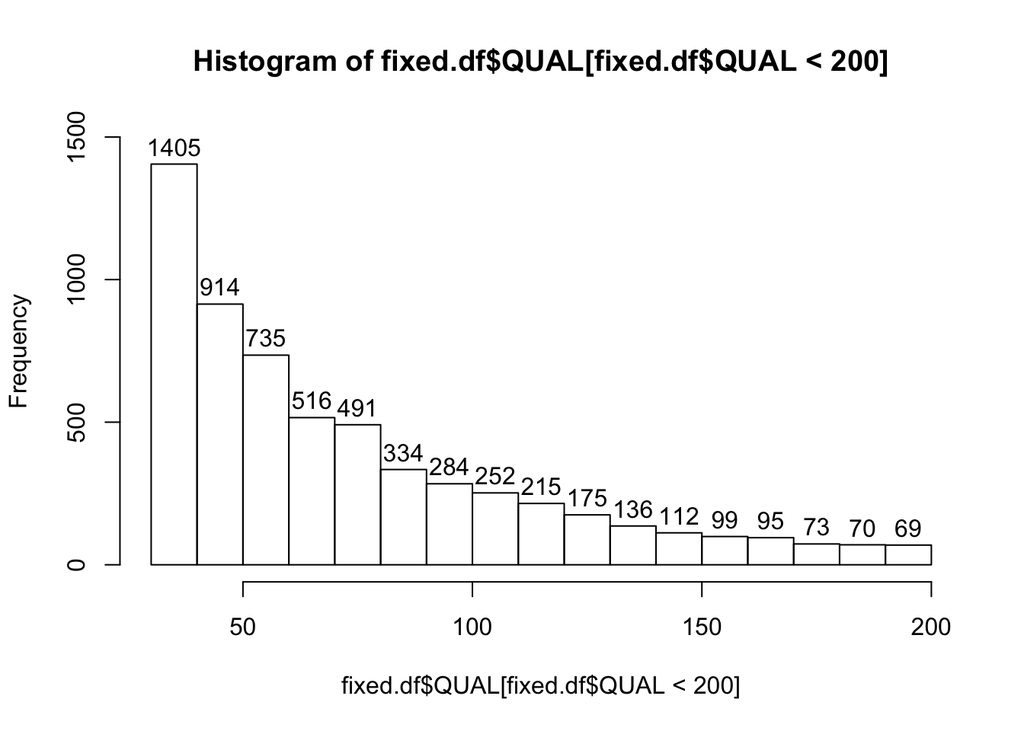

```r
hist(fixed.df$QUAL[fixed.df$QUAL<200], lab=T, ylim=c(0,1500))
```

```r
sum(fixed.df$QUAL < 150)/length(fixed.df$QUAL)
```

```
## [1] 0.4316385
```

# DP

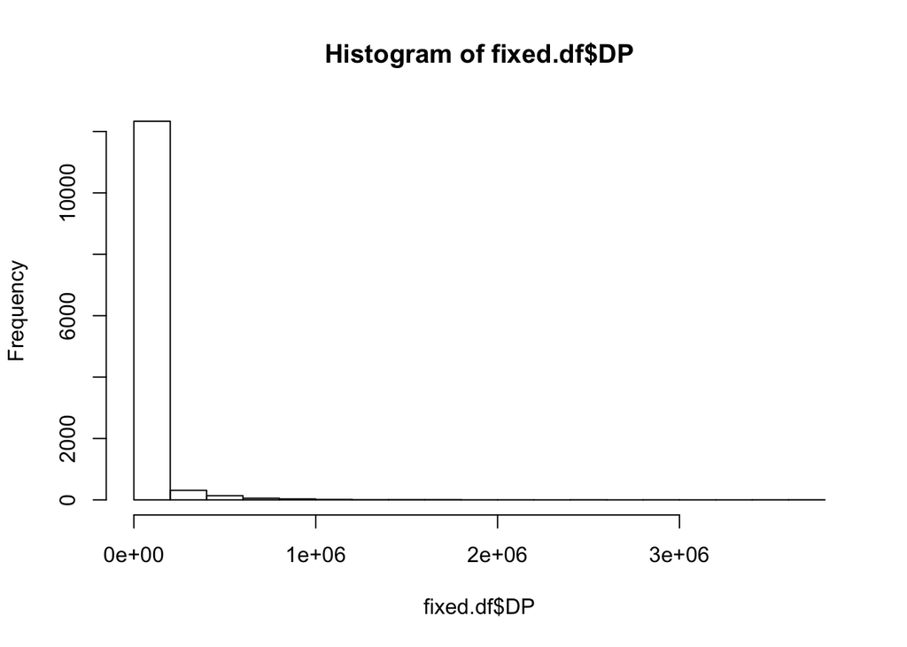

```r
hist(fixed.df$DP)
```

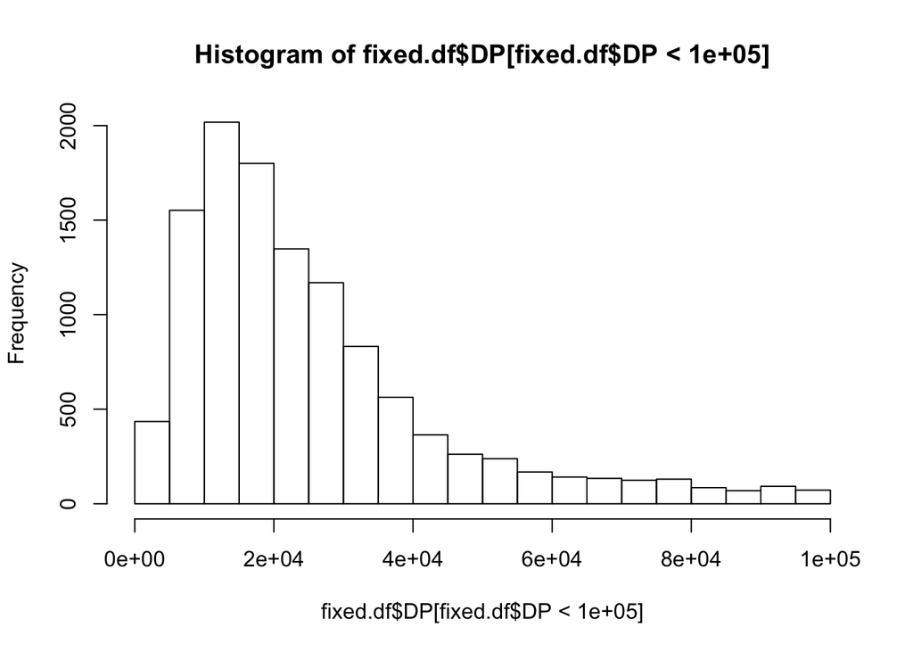

```r
hist(fixed.df$DP[fixed.df$DP<100000])
```

```r
sum(fixed.df$DP < 7390)/length(fixed.df$DP)
```

```
## [1] 0.07866997
```

```r
sum(fixed.df$DP >= 7390 & fixed.df$FILTER=="PASS" )/length(fixed.df$DP)
```

```
## [1] 0.6326151
```

```r
sum(fixed.df$DP >= 7390 & fixed.df$FILTER=="PASS" )
```

```
## [1] 8162
```

```r
max(fixed.df$DP)
```

```
## [1] 3754058
```

```r
sum(fixed.df$DP > 100000 & fixed.df$FILTER=="PASS" )/length(fixed.df$DP)
```

```
## [1] 0.08122772
```

```r
sum(fixed.df$DP > 100000 & fixed.df$FILTER=="PASS" )
```

```
## [1] 1048
```

```r
sum(fixed.df$DP >= 7390 & fixed.df$FILTER=="PASS" & fixed.df$DP < 100000)
```

```
## [1] 7114
```

# VQSLOD

```r
sum(is.na(fixed.df$AS_VQSLOD))
```

```
## [1] 0
```

```r
vqslod <- as.numeric(fixed.df$AS_VQSLOD)
sum(is.na(vqslod))
```

```
## [1] 538
```

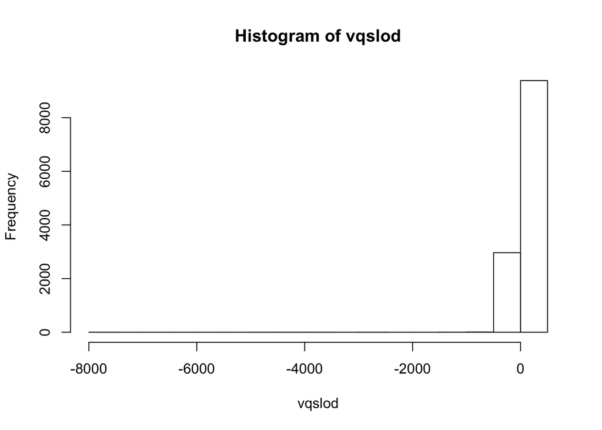

```r
hist(vqslod)
```

```r
max(vqslod, na.rm=T)
```

```
## [1] 24.8846
```

```r
hist(vqslod[vqslod > -25], breaks=100)

min(vqslod[fixed.df$FILTER=="PASS"], na.rm=T)
```

```
## [1] 0.9333
```

```r
max(vqslod[fixed.df$FILTER=="PASS"], na.rm=T)
```

```
## [1] 24.8846
```

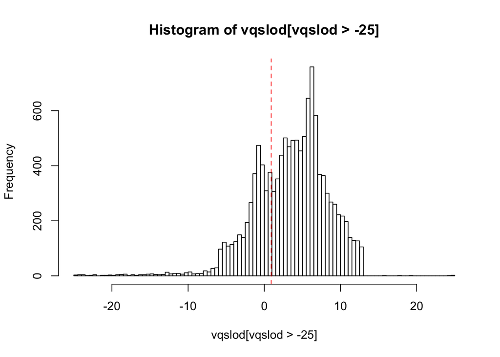

```r
abline(v=0.9, col="Red", lty=2)
```

```r
rm(vqslod)
```

# Save results

```r
save.image(paste(base_folder, "explore_ampliseq_vqsr_vcf.RData", sep="/"))
```

# Final section

```r
ls()
```

```
## [1] "base_folder" "fixed.df"    "gt_num.mx"   "meta.df"
```

```r
Sys.time()
```

```
## [1] "2019-03-15 22:03:39 GMT"
```